# PREDICTING THE QUALITY OF BARBELL LIFTS USING MACHINE LEARNING AND PERSONAL-ACTIVITY DATA

### PREDICTING THE QUALITY OF BARBELL LIFTS USING MACHINE LEARNING AND PERSONAL-ACTIVITY DATA

### Introduction

Many devices are becoming available that allow to quantify self-movement during the practice of sports and to produce large amounts of data that need to be interpreted. One basic goal most people have is to measure *the amount* of an activity they perform (e.g. distance run or lifts done), but a more profitable–and also more challenging–use of the data would be to predict *the quality* of the performance. With this goal, the Weight Lifting Exercise Dataset was created (see http://groupware.les.inf.puc-rio.br/har). Data were collected by asking 6 participants to wear belt, forearm, arm, and dumbell accelerometers and to perform barbell lifts in various ways, both correct and incorrect. The data was classified in 5 separate classes.

### Goal

The goal of this project was to build a classification model to predict the quality of barbell lifts from newly collected data. For this, we used a large training set, containing information about the class of each measure, and a smalled test set for which class information is not available. We aimed at predicting the class of each test measure from the model.

### Model construction

First, we loaded the training and testing data sets, originally in csv format, as follows:

```r
train <- read.csv("pml-training.csv", header = TRUE)
dim(train)
```

```
## [1] 19622   160
```

```r
test <- read.csv("pml-testing.csv", header = TRUE)
dim(test)
```

```
## [1]  20 160
```

We used the caret package:

```r
library(caret)
```

A brief exploration of the data showed that there are 160 variables, but most of them are statistical data, e.g. averages, standard deviations and kurtosis, which are either empty or not available, and in any case have no predictive value.

```r
train[1, ]
```

```
##   X user_name raw_timestamp_part_1 raw_timestamp_part_2   cvtd_timestamp
## 1 1  carlitos           1323084231               788290 05/12/2011 11:23
##   new_window num_window roll_belt pitch_belt yaw_belt total_accel_belt
## 1         no         11      1.41       8.07    -94.4                3
##   kurtosis_roll_belt kurtosis_picth_belt kurtosis_yaw_belt
## 1
##   skewness_roll_belt skewness_roll_belt.1 skewness_yaw_belt max_roll_belt
## 1                                                                      NA
##   max_picth_belt max_yaw_belt min_roll_belt min_pitch_belt min_yaw_belt
## 1             NA                         NA             NA
##   amplitude_roll_belt amplitude_pitch_belt amplitude_yaw_belt
## 1                  NA                   NA
##   var_total_accel_belt avg_roll_belt stddev_roll_belt var_roll_belt
## 1                   NA            NA               NA            NA
##   avg_pitch_belt stddev_pitch_belt var_pitch_belt avg_yaw_belt
## 1             NA                NA             NA           NA
##   stddev_yaw_belt var_yaw_belt gyros_belt_x gyros_belt_y gyros_belt_z
## 1              NA           NA            0            0        -0.02
##   accel_belt_x accel_belt_y accel_belt_z magnet_belt_x magnet_belt_y
## 1          -21            4           22            -3           599
##   magnet_belt_z roll_arm pitch_arm yaw_arm total_accel_arm var_accel_arm
## 1          -313     -128      22.5    -161              34            NA
##   avg_roll_arm stddev_roll_arm var_roll_arm avg_pitch_arm stddev_pitch_arm
## 1           NA              NA           NA            NA               NA
##   var_pitch_arm avg_yaw_arm stddev_yaw_arm var_yaw_arm gyros_arm_x
## 1            NA          NA             NA          NA           0
##   gyros_arm_y gyros_arm_z accel_arm_x accel_arm_y accel_arm_z magnet_arm_x
## 1           0       -0.02        -288         109        -123         -368
##   magnet_arm_y magnet_arm_z kurtosis_roll_arm kurtosis_picth_arm
## 1          337          516
##   kurtosis_yaw_arm skewness_roll_arm skewness_pitch_arm skewness_yaw_arm
## 1
##   max_roll_arm max_picth_arm max_yaw_arm min_roll_arm min_pitch_arm
## 1           NA            NA          NA           NA            NA
##   min_yaw_arm amplitude_roll_arm amplitude_pitch_arm amplitude_yaw_arm
## 1          NA                 NA                  NA                NA
##   roll_dumbbell pitch_dumbbell yaw_dumbbell kurtosis_roll_dumbbell
## 1         13.05         -70.49       -84.87
##   kurtosis_picth_dumbbell kurtosis_yaw_dumbbell skewness_roll_dumbbell
## 1
```

[output cut: 25 more lines]

```
## 1                NA                               NA                NA
##   min_yaw_forearm amplitude_roll_forearm amplitude_pitch_forearm
## 1                                     NA                      NA
##   amplitude_yaw_forearm total_accel_forearm var_accel_forearm
## 1                                        36                NA
##   avg_roll_forearm stddev_roll_forearm var_roll_forearm avg_pitch_forearm
## 1               NA                  NA               NA                NA
##   stddev_pitch_forearm var_pitch_forearm avg_yaw_forearm
## 1                   NA                NA              NA
##   stddev_yaw_forearm var_yaw_forearm gyros_forearm_x gyros_forearm_y
## 1                 NA              NA            0.03               0
##   gyros_forearm_z accel_forearm_x accel_forearm_y accel_forearm_z
## 1           -0.02             192             203            -215
##   magnet_forearm_x magnet_forearm_y magnet_forearm_z classe
## 1              -17              654              476      A
```

Therefore, we removed all empty and NA variables:

```r
trainsubset <- train[, !is.na(train[1, ]) & train[1, ] != ""]
```

Moreover, information about the user and timestamps (see first 7 columns) is not useful either, so we removed it as well:

```r
trainsubset2 <- trainsubset[, 8:60]
dim(trainsubset2)
```

```
## [1] 19622    53
```

As shown, the result is a set with 53 variables, including “classe”, which is the class of the measure that the model should predict from the rest of the variables.

A brief exploratory search of features, using featurePlot, did not reveal any simple correlations between variables. For instance:

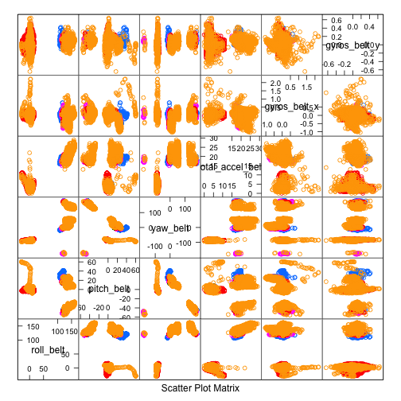

```r
featurePlot(trainsubset2[1:6], trainsubset2$classe, plot = "pairs")
```

For this reason, a model including all variables seemed reasonable, at least in the first instance.

Before building a prediction model, it was necessary to split the training data into a training set and a testing set, in the usual proportion of 60:40:

```r
inTrain <- createDataPartition(y = trainsubset2$classe, p = 0.6, list = FALSE)
training <- trainsubset2[inTrain, ]
testing <- trainsubset2[-inTrain, ]
```

It is important to differentiate the test set that we used for validation purposes (testing) from the test set for which class values must be predicted (test).

Random forests are powerful general classification algorithms that require few initial assumptions and therefore are a good choice for the kind of complex data that we have. A fit to a random forest can be carried out as follows:

```r
modFit <- train(classe ~ ., data = training, method = "rf", prox = TRUE)
```

The result was:

```r
modFit
```

```
## Random Forest
##
## 11776 samples
##    52 predictors
##     5 classes: 'A', 'B', 'C', 'D', 'E'
##
## No pre-processing
## Resampling: Bootstrapped (25 reps)
##
## Summary of sample sizes: 11776, 11776, 11776, 11776, 11776, 11776, ...
##
## Resampling results across tuning parameters:
##
##   mtry  Accuracy  Kappa  Accuracy SD  Kappa SD
##   2     0.985     0.981  0.00224      0.00283
##   27    0.985     0.981  0.00223      0.00281
##   52    0.976     0.969  0.00483      0.0061
##
## Accuracy was used to select the optimal model using  the largest value.
## The final value used for the model was mtry = 2.
```

As shown, the funcion train attempted several models with different numbers of variables per level (mtry). The best value found was mtry=2. The accuracy was not perfect (98.5% accuracy), so we tried to clean the data further. In particular, removing rows for which new_window==“yes”, which seem to follow a slightly different trend than the rest of the rows did not improved the model. Therefore, we used the initial fit to validate and predict classes. It is expected that the accuracy found by validation and in the target (test) set should be also around 98.5%. Indeed, it was better (see below).

### Validation

To validate the model, we used it to predict the (known) classes of the testing set that we obtained by splitting the training data (see above).

```r
pred <- predict(modFit, testing)
```

The quality of the fit can be estimated using a confusion matrix:

```r
confusionMatrix(pred, testing$classe)
```

```
## Confusion Matrix and Statistics
##
##           Reference
## Prediction    A    B    C    D    E
##          A 2231   10    0    0    0
##          B    1 1503    4    0    0
##          C    0    5 1364   25    0
##          D    0    0    0 1259    8
##          E    0    0    0    2 1434
##
## Overall Statistics
##
##                Accuracy : 0.993
##                  95% CI : (0.9909, 0.9947)
##     No Information Rate : 0.2845
##     P-Value [Acc > NIR] : < 2.2e-16
##
##                   Kappa : 0.9911
##  Mcnemar's Test P-Value : NA
##
## Statistics by Class:
##
##                      Class: A Class: B Class: C Class: D Class: E
## Sensitivity            0.9996   0.9901   0.9971   0.9790   0.9945
## Specificity            0.9982   0.9992   0.9954   0.9988   0.9997
## Pos Pred Value         0.9955   0.9967   0.9785   0.9937   0.9986
## Neg Pred Value         0.9998   0.9976   0.9994   0.9959   0.9988
## Prevalence             0.2845   0.1935   0.1744   0.1639   0.1838
## Detection Rate         0.2843   0.1916   0.1738   0.1605   0.1828
## Detection Prevalence   0.2856   0.1922   0.1777   0.1615   0.1830
## Balanced Accuracy      0.9989   0.9947   0.9962   0.9889   0.9971
```

This shows that, in this case, estimating the accuracy of the model by comparing the predicted class with the known class produces an excellent value of 99.3%.

### Prediction of classes

The purpose of the model is, of course, to classify new data. In this assignment, we want to predict the quality classes of the measurements in the test set. Therefore, we applied the model to the test (target) data:

```r
pred_test <- predict(modFit, test)
pred_test
```

```
##  [1] B A B A A E D B A A B C B A E E A B B B
## Levels: A B C D E
```

In general, there is no guarantee that the predicted class will be correct. However, the high accuracy obtained in the validation step suggests that most predictions will indeed be correct, and, in fact, all of them were in this assignment.

### Conclusion

A random forest classification model of personal-activity data, collected by volunteers wearing a set of accelerometers during weight lifting exercises, is able to predict the quality of unclassified exercise data with an accuracy of over 99%. The model uses data from 52 variables and decides which out of five levels (labelled A,B,C,D,E) the data belong to. The model may potentially be used to improve the quality of training programs.

### References

Ugulino, W.; Cardador, D.; Vega, K.; Velloso, E.; Milidiu, R.; Fuks, H. Wearable Computing: Accelerometers' Data Classification of Body Postures and Movements. Proceedings of 21st Brazilian Symposium on Artificial Intelligence. Advances in Artificial Intelligence - SBIA 2012. In: Lecture Notes in Computer Science. , pp. 52-61. Curitiba, PR: Springer Berlin / Heidelberg, 2012. ISBN 978-3-642-34458-9. DOI: 10.1007/978-3-642-34459-6_6.

Read more: http://groupware.les.inf.puc-rio.br/har#ixzz35O9RuNWh

Velloso, E.; Bulling, A.; Gellersen, H.; Ugulino, W.; Fuks, H. Qualitative Activity Recognition of Weight Lifting Exercises. Proceedings of 4th International Conference in Cooperation with SIGCHI (Augmented Human '13) . Stuttgart, Germany: ACM SIGCHI, 2013.

Read more: http://groupware.les.inf.puc-rio.br/har#ixzz35OD1ubAF